# Table of Contents

### Customer Segmentation

- Freelancers have higher rate of purchase of travel package. That category of customers should be targeted.
- Customers who travel in a group of 5 or who travel alone have not bought any travel package. They should be incentivized to buy more
- Customers from Tier2 and Tier3 cities have higher percentage of buying a travel package but the overall purchase number is low. This category has to be targeted.
- High income and older group of customers have less probability of purchasing a travel package - they should be incentivized to buy the travel package

## Data Preprocessing

### Outliers

```python
def outlier_detection_using_IQR(column):
    quartiles = np.quantile(df[column][df[column].notnull()], [0.25, 0.75])
    power_4iqr = 4 * (quartiles[1] - quartiles[0])
    print(f"Q1 = {quartiles[0]}, Q3 = {quartiles[1]}, 4*IQR = {power_4iqr}")
    outlier = df.loc[
        np.abs(df[column] - df[column].median()) > power_4iqr, column,
    ]
    return outlier
```

```python
def mark_outlier_as_NAN(column):
    quartiles = np.quantile(df[column][df[column].notnull()], [0.25, 0.75])
    power_4iqr = 4 * (quartiles[1] - quartiles[0])
    df.loc[np.abs(df[column] - df[column].median()) > power_4iqr, column,] = np.nan
```

**checking extreme values in NumberOfTrips**

```python
df.sort_values(by=["NumberOfTrips"], ascending=False).head(5)
```

|  | ProdTaken | Age | TypeofContact | CityTier | Occupation | Gender | NumberOfPersonVisiting | NumberOfFollowups | PreferredPropertyStar | MaritalStatus | NumberOfTrips | Passport | PitchSatisfactionScore | OwnCar | NumberOfChildrenVisiting | Designation | MonthlyIncome |
| --- | --- | --- | --- | --- | --- | --- | --- | --- | --- | --- | --- | --- | --- | --- | --- | --- | --- |
| 3260 | 0 | 40.0 | Company Invited | 1 | Salaried | Male | 4 | 4.0 | 4.0 | Unmarried | 22.0 | 0 | 2 | 1 | 1.0 | Manager | 25460.0 |
| 816 | 0 | 39.0 | Company Invited | 1 | Salaried | Male | 3 | 3.0 | 4.0 | Unmarried | 21.0 | 0 | 2 | 1 | 0.0 | Manager | 21782.0 |
| 2829 | 1 | 31.0 | Company Invited | 1 | Large Business | Male | 3 | 4.0 | 3.0 | Single | 20.0 | 1 | 4 | 1 | 2.0 | Executive | 20963.0 |
| 385 | 1 | 30.0 | Company Invited | 1 | Large Business | Male | 2 | 3.0 | 3.0 | Single | 19.0 | 1 | 4 | 1 | 1.0 | Executive | 17285.0 |
| 3074 | 0 | 23.0 | Self Enquiry | 1 | Salaried | Male | 3 | 5.0 | 3.0 | Divorced | 8.0 | 0 | 2 | 1 | 1.0 | Manager | 23453.0 |

- Out of 4888 customers, only 4 have extreme values - 22,21,20,19

```python
outlier_no_of_trips = outlier_detection_using_IQR("NumberOfTrips")
outlier_no_of_trips
```

```
Q1 = 2.0, Q3 = 4.0, 4*IQR = 8.0
```

```
385     19.0
816     21.0
2829    20.0
3260    22.0
Name: NumberOfTrips, dtype: float64
```

```python
# We can mark these as NAN and handle it as missing value
mark_outlier_as_NAN("NumberOfTrips")
```

**checking outliers in MonthlyIncome**

```python
df.sort_values(by=["MonthlyIncome"], ascending=False).head(5)
```

|  | ProdTaken | Age | TypeofContact | CityTier | Occupation | Gender | NumberOfPersonVisiting | NumberOfFollowups | PreferredPropertyStar | MaritalStatus | NumberOfTrips | Passport | PitchSatisfactionScore | OwnCar | NumberOfChildrenVisiting | Designation | MonthlyIncome |
| --- | --- | --- | --- | --- | --- | --- | --- | --- | --- | --- | --- | --- | --- | --- | --- | --- | --- |
| 2482 | 0 | 37.0 | Self Enquiry | 1 | Salaried | Female | 3 | 5.0 | 5.0 | Divorced | 2.0 | 1 | 2 | 1 | 1.0 | Executive | 98678.0 |
| 38 | 0 | 36.0 | Self Enquiry | 1 | Salaried | Female | 2 | 4.0 | NaN | Divorced | 1.0 | 1 | 2 | 1 | 0.0 | Executive | 95000.0 |
| 4104 | 0 | 53.0 | Self Enquiry | 1 | Salaried | Male | 4 | 5.0 | NaN | Married | 2.0 | 0 | 1 | 1 | 3.0 | VP | 38677.0 |
| 2634 | 0 | 53.0 | Self Enquiry | 1 | Salaried | Male | 4 | 5.0 | NaN | Divorced | 2.0 | 0 | 2 | 1 | 2.0 | VP | 38677.0 |
| 4660 | 0 | 42.0 | Company Invited | 1 | Salaried | Female | 3 | 6.0 | NaN | Married | 3.0 | 0 | 4 | 1 | 2.0 | VP | 38651.0 |

- Two customers have Monthly income "98678" and "95000" which is way more than the rest of the 4886 customers

```python
outlier_income = outlier_detection_using_IQR("MonthlyIncome")
outlier_income
```

```
Q1 = 20346.0, Q3 = 25571.0, 4*IQR = 20900.0
```

```
38      95000.0
142      1000.0
2482    98678.0
Name: MonthlyIncome, dtype: float64
```

```python
# We can mark these as NAN and handle it as missing value
mark_outlier_as_NAN("MonthlyIncome")
```

### Missing Value Treatment

```python
# let's check again for missing values
df.isnull().sum().sort_values(ascending=False)
```

```
MonthlyIncome               236
Age                         226
NumberOfTrips               144
NumberOfChildrenVisiting     66
NumberOfFollowups            45
PreferredPropertyStar        26
TypeofContact                25
NumberOfPersonVisiting        0
Gender                        0
Occupation                    0
MaritalStatus                 0
CityTier                      0
Passport                      0
PitchSatisfactionScore        0
OwnCar                        0
Designation                   0
ProdTaken                     0
dtype: int64
```

**Let's look at the rows where TypeofContact is missing.**

```python
df[df["TypeofContact"].isnull()].head(10)
```

|  | ProdTaken | Age | TypeofContact | CityTier | Occupation | Gender | NumberOfPersonVisiting | NumberOfFollowups | PreferredPropertyStar | MaritalStatus | NumberOfTrips | Passport | PitchSatisfactionScore | OwnCar | NumberOfChildrenVisiting | Designation | MonthlyIncome |
| --- | --- | --- | --- | --- | --- | --- | --- | --- | --- | --- | --- | --- | --- | --- | --- | --- | --- |
| 224 | 0 | 31.0 | NaN | 1 | Small Business | Male | 2 | 5.0 | 3.0 | Divorced | 1.0 | 0 | 3 | 1 | 0.0 | Manager | NaN |
| 571 | 0 | 26.0 | NaN | 1 | Salaried | Female | 3 | 5.0 | 3.0 | Married | 4.0 | 0 | 4 | 1 | 2.0 | Executive | NaN |
| 572 | 0 | 29.0 | NaN | 1 | Small Business | Female | 3 | 3.0 | 3.0 | Divorced | 5.0 | 0 | 2 | 1 | 0.0 | Manager | NaN |
| 576 | 0 | 27.0 | NaN | 3 | Small Business | Male | 2 | 3.0 | 3.0 | Divorced | 1.0 | 0 | 3 | 0 | 1.0 | Manager | NaN |
| 579 | 0 | 34.0 | NaN | 1 | Small Business | Female | 2 | 4.0 | 5.0 | Single | 2.0 | 0 | 2 | 1 | 1.0 | Executive | NaN |
| 598 | 1 | 28.0 | NaN | 1 | Small Business | Male | 2 | 3.0 | 3.0 | Single | 7.0 | 0 | 3 | 0 | 0.0 | Executive | NaN |
| 622 | 0 | 32.0 | NaN | 3 | Salaried | Male | 3 | 3.0 | 3.0 | Married | 3.0 | 0 | 2 | 0 | 0.0 | Manager | NaN |
| 724 | 0 | 24.0 | NaN | 1 | Small Business | Female | 2 | 4.0 | 3.0 | Married | 2.0 | 0 | 3 | 1 | 1.0 | Manager | NaN |
| 843 | 0 | 26.0 | NaN | 1 | Small Business | Male | 2 | 1.0 | 3.0 | Divorced | 2.0 | 0 | 5 | 1 | 1.0 | Executive | NaN |
| 1021 | 1 | 25.0 | NaN | 3 | Salaried | Male | 3 | 4.0 | 5.0 | Divorced | 4.0 | 0 | 1 | 1 | 0.0 | Executive | NaN |

```python
# We can impute the missing values with the mode of the column (since this is a categorical variable)
mode = df["TypeofContact"].mode()[0]
df["TypeofContact"].fillna(mode, inplace=True)
df.isnull().sum().sort_values(ascending=False)
```

```
MonthlyIncome               236
Age                         226
NumberOfTrips               144
NumberOfChildrenVisiting     66
NumberOfFollowups            45
PreferredPropertyStar        26
NumberOfPersonVisiting        0
Gender                        0
Occupation                    0
MaritalStatus                 0
CityTier                      0
Passport                      0
PitchSatisfactionScore        0
OwnCar                        0
TypeofContact                 0
Designation                   0
ProdTaken                     0
dtype: int64
```

**Let's look at a few rows where PreferredPropertyStar is missing.**

```python
df[df["PreferredPropertyStar"].isnull()].head(10)
```

|  | ProdTaken | Age | TypeofContact | CityTier | Occupation | Gender | NumberOfPersonVisiting | NumberOfFollowups | PreferredPropertyStar | MaritalStatus | NumberOfTrips | Passport | PitchSatisfactionScore | OwnCar | NumberOfChildrenVisiting | Designation | MonthlyIncome |
| --- | --- | --- | --- | --- | --- | --- | --- | --- | --- | --- | --- | --- | --- | --- | --- | --- | --- |
| 38 | 0 | 36.0 | Self Enquiry | 1 | Salaried | Female | 2 | 4.0 | NaN | Divorced | 1.0 | 1 | 2 | 1 | 0.0 | Executive | NaN |
| 2609 | 0 | 51.0 | Self Enquiry | 1 | Salaried | Female | 3 | 4.0 | NaN | Single | 5.0 | 0 | 5 | 1 | 1.0 | VP | 38604.0 |
| 2634 | 0 | 53.0 | Self Enquiry | 1 | Salaried | Male | 4 | 5.0 | NaN | Divorced | 2.0 | 0 | 2 | 1 | 2.0 | VP | 38677.0 |
| 3012 | 1 | 56.0 | Self Enquiry | 1 | Small Business | Male | 4 | 4.0 | NaN | Divorced | 7.0 | 1 | 2 | 1 | 3.0 | VP | 38537.0 |
| 3190 | 0 | 42.0 | Company Invited | 1 | Salaried | Female | 3 | 6.0 | NaN | Married | 3.0 | 0 | 4 | 1 | 1.0 | VP | 38651.0 |
| 3193 | 1 | 53.0 | Self Enquiry | 3 | Small Business | Female | 3 | 6.0 | NaN | Divorced | 3.0 | 0 | 3 | 1 | 1.0 | VP | 38523.0 |
| 3214 | 0 | 47.0 | Self Enquiry | 1 | Small Business | Male | 3 | 4.0 | NaN | Married | 2.0 | 0 | 5 | 1 | 2.0 | VP | 38305.0 |
| 3295 | 0 | 57.0 | Self Enquiry | 1 | Large Business | Female | 4 | 4.0 | NaN | Married | 6.0 | 0 | 4 | 0 | 3.0 | VP | 38621.0 |
| 3342 | 0 | 44.0 | Self Enquiry | 1 | Salaried | Male | 4 | 6.0 | NaN | Divorced | 5.0 | 0 | 5 | 1 | 3.0 | VP | 38418.0 |
| 3362 | 0 | 52.0 | Company Invited | 3 | Salaried | Male | 3 | 4.0 | NaN | Married | 6.0 | 1 | 4 | 1 | 2.0 | VP | 38525.0 |

```python
# We can group the customers by occupation, designation
# and fill the missing values with most frequent value of each group
df.groupby(["Occupation", "Designation"], as_index=False)["PreferredPropertyStar"].agg(
    lambda x: x.value_counts().index[0]
)
```

|  | Occupation | Designation | PreferredPropertyStar |
| --- | --- | --- | --- |
| 0 | Free Lancer | AVP | NaN |
| 1 | Free Lancer | Executive | 3.0 |
| 2 | Free Lancer | Manager | NaN |
| 3 | Free Lancer | Senior Manager | NaN |
| 4 | Free Lancer | VP | NaN |
| 5 | Large Business | AVP | 4.0 |
| 6 | Large Business | Executive | 3.0 |
| 7 | Large Business | Manager | 3.0 |
| 8 | Large Business | Senior Manager | 3.0 |
| 9 | Large Business | VP | 3.0 |
| 10 | Salaried | AVP | 3.0 |
| 11 | Salaried | Executive | 3.0 |
| 12 | Salaried | Manager | 3.0 |
| 13 | Salaried | Senior Manager | 3.0 |
| 14 | Salaried | VP | 3.0 |
| 15 | Small Business | AVP | 3.0 |
| 16 | Small Business | Executive | 3.0 |
| 17 | Small Business | Manager | 3.0 |
| 18 | Small Business | Senior Manager | 3.0 |
| 19 | Small Business | VP | 3.0 |

```python
df["PreferredPropertyStar"] = df.groupby(["Occupation", "Designation"])[
    "PreferredPropertyStar"
].transform(lambda x: x.fillna(x.value_counts().index[0]))
df.isnull().sum().sort_values(ascending=False)
```

```
MonthlyIncome               236
Age                         226
NumberOfTrips               144
NumberOfChildrenVisiting     66
NumberOfFollowups            45
Designation                   0
OwnCar                        0
PitchSatisfactionScore        0
Passport                      0
ProdTaken                     0
MaritalStatus                 0
NumberOfPersonVisiting        0
Gender                        0
Occupation                    0
CityTier                      0
TypeofContact                 0
PreferredPropertyStar         0
dtype: int64
```

**Let's look at a few rows where NumberOfFollowups is missing.**

```python
df[df["NumberOfFollowups"].isnull()].head(10)
```

|  | ProdTaken | Age | TypeofContact | CityTier | Occupation | Gender | NumberOfPersonVisiting | NumberOfFollowups | PreferredPropertyStar | MaritalStatus | NumberOfTrips | Passport | PitchSatisfactionScore | OwnCar | NumberOfChildrenVisiting | Designation | MonthlyIncome |
| --- | --- | --- | --- | --- | --- | --- | --- | --- | --- | --- | --- | --- | --- | --- | --- | --- | --- |
| 79 | 0 | 46.0 | Self Enquiry | 2 | Small Business | Male | 3 | NaN | 4.0 | Married | 1.0 | 1 | 5 | 0 | 1.0 | Manager | 20021.0 |
| 94 | 0 | 32.0 | Self Enquiry | 3 | Small Business | Male | 2 | NaN | 3.0 | Single | 2.0 | 0 | 5 | 1 | 0.0 | Manager | 20010.0 |
| 96 | 0 | 24.0 | Self Enquiry | 3 | Salaried | Female | 2 | NaN | 3.0 | Divorced | 1.0 | 0 | 4 | 1 | 0.0 | Manager | 19999.0 |
| 122 | 1 | 56.0 | Self Enquiry | 1 | Salaried | Female | 3 | NaN | 4.0 | Divorced | 1.0 | 1 | 5 | 1 | 1.0 | Executive | 19963.0 |
| 135 | 0 | 36.0 | Self Enquiry | 1 | Small Business | Male | 2 | NaN | 4.0 | Married | 7.0 | 0 | 4 | 1 | 1.0 | Manager | 19941.0 |
| 174 | 0 | 45.0 | Self Enquiry | 3 | Salaried | Female | 1 | NaN | 5.0 | Married | 5.0 | 1 | 4 | 0 | 0.0 | Manager | 20006.0 |
| 317 | 1 | 52.0 | Self Enquiry | 1 | Small Business | Male | 2 | NaN | 4.0 | Divorced | 3.0 | 0 | 2 | 1 | 1.0 | Manager | 19941.0 |
| 322 | 0 | 32.0 | Self Enquiry | 1 | Small Business | Female | 3 | NaN | 3.0 | Single | 1.0 | 0 | 3 | 1 | 2.0 | Manager | 20055.0 |
| 376 | 0 | 51.0 | Self Enquiry | 3 | Salaried | Female | 2 | NaN | 3.0 | Divorced | 5.0 | 0 | 3 | 0 | 1.0 | Manager | 19936.0 |
| 532 | 0 | 47.0 | Self Enquiry | 3 | Small Business | Male | 2 | NaN | 5.0 | Single | 3.0 | 0 | 2 | 0 | 1.0 | Manager | 19960.0 |

```python
# We can group the customers by TypeofContact and fill the missing values with median value of each group
df.groupby(["TypeofContact"], as_index=False)["NumberOfFollowups"].median()
```

|  | TypeofContact | NumberOfFollowups |
| --- | --- | --- |
| 0 | Company Invited | 4.0 |
| 1 | Self Enquiry | 4.0 |

```python
df["NumberOfFollowups"] = df.groupby(["TypeofContact"])["NumberOfFollowups"].transform(
    lambda x: x.fillna(x.median())
)
df.isnull().sum().sort_values(ascending=False)
```

```
MonthlyIncome               236
Age                         226
NumberOfTrips               144
NumberOfChildrenVisiting     66
MaritalStatus                 0
Designation                   0
OwnCar                        0
PitchSatisfactionScore        0
Passport                      0
ProdTaken                     0
NumberOfFollowups             0
NumberOfPersonVisiting        0
Gender                        0
Occupation                    0
CityTier                      0
TypeofContact                 0
PreferredPropertyStar         0
dtype: int64
```

**Let's look at a few rows where NumberOfChildrenVisiting is missing.**

```python
df[df["NumberOfChildrenVisiting"].isnull()].head(10)
```

|  | ProdTaken | Age | TypeofContact | CityTier | Occupation | Gender | NumberOfPersonVisiting | NumberOfFollowups | PreferredPropertyStar | MaritalStatus | NumberOfTrips | Passport | PitchSatisfactionScore | OwnCar | NumberOfChildrenVisiting | Designation | MonthlyIncome |
| --- | --- | --- | --- | --- | --- | --- | --- | --- | --- | --- | --- | --- | --- | --- | --- | --- | --- |
| 165 | 0 | 50.0 | Self Enquiry | 1 | Salaried | Female | 2 | 3.0 | 4.0 | Single | 4.0 | 0 | 5 | 1 | NaN | VP | 34926.0 |
| 190 | 0 | 52.0 | Self Enquiry | 1 | Salaried | Male | 3 | 4.0 | 3.0 | Divorced | 1.0 | 0 | 2 | 1 | NaN | VP | 34999.0 |
| 568 | 1 | 55.0 | Self Enquiry | 1 | Small Business | Male | 3 | 3.0 | 5.0 | Divorced | 6.0 | 1 | 2 | 1 | NaN | VP | 34859.0 |
| 746 | 0 | 41.0 | Company Invited | 1 | Salaried | Female | 2 | 5.0 | 3.0 | Married | 2.0 | 0 | 4 | 1 | NaN | VP | 34973.0 |
| 749 | 1 | 52.0 | Self Enquiry | 3 | Small Business | Female | 2 | 5.0 | 3.0 | Divorced | 2.0 | 0 | 3 | 1 | NaN | VP | 34845.0 |
| 851 | 0 | 56.0 | Self Enquiry | 1 | Large Business | Female | 3 | 3.0 | 5.0 | Married | 5.0 | 0 | 4 | 0 | NaN | VP | 34943.0 |
| 898 | 0 | 43.0 | Self Enquiry | 1 | Salaried | Male | 3 | 5.0 | 3.0 | Divorced | 4.0 | 0 | 5 | 1 | NaN | VP | 34740.0 |
| 918 | 0 | 51.0 | Company Invited | 3 | Salaried | Male | 2 | 3.0 | 4.0 | Married | 5.0 | 1 | 4 | 1 | NaN | VP | 34847.0 |
| 956 | 0 | 56.0 | Self Enquiry | 2 | Salaried | Male | 2 | 3.0 | 4.0 | Single | 7.0 | 0 | 4 | 1 | NaN | VP | 34717.0 |
| 1009 | 0 | 58.0 | Self Enquiry | 1 | Small Business | Female | 3 | 3.0 | 5.0 | Divorced | 4.0 | 1 | 1 | 1 | NaN | VP | 34701.0 |

```python
# We can group the customers by MaritalStatus, Gender and fill the missing values with median value of each group
df.groupby(["MaritalStatus", "Gender"], as_index=False)[
    "NumberOfChildrenVisiting"
].median()
```

|  | MaritalStatus | Gender | NumberOfChildrenVisiting |
| --- | --- | --- | --- |
| 0 | Divorced | Female | 1.0 |
| 1 | Divorced | Male | 1.0 |
| 2 | Married | Female | 1.0 |
| 3 | Married | Male | 1.0 |
| 4 | Single | Female | 1.0 |
| 5 | Single | Male | 1.0 |
| 6 | Unmarried | Female | 1.0 |
| 7 | Unmarried | Male | 1.0 |

```python
df["NumberOfChildrenVisiting"] = df.groupby(["MaritalStatus", "Gender"])[
    "NumberOfChildrenVisiting"
].transform(lambda x: x.fillna(x.median()))
df.isnull().sum().sort_values(ascending=False)
```

```
MonthlyIncome               236
Age                         226
NumberOfTrips               144
MaritalStatus                 0
Designation                   0
NumberOfChildrenVisiting      0
OwnCar                        0
PitchSatisfactionScore        0
Passport                      0
ProdTaken                     0
NumberOfFollowups             0
NumberOfPersonVisiting        0
Gender                        0
Occupation                    0
CityTier                      0
TypeofContact                 0
PreferredPropertyStar         0
dtype: int64
```

**Let's look at a few rows where NumberOfTrips is missing.**

```python
df[df["NumberOfTrips"].isnull()].head(10)
```

|  | ProdTaken | Age | TypeofContact | CityTier | Occupation | Gender | NumberOfPersonVisiting | NumberOfFollowups | PreferredPropertyStar | MaritalStatus | NumberOfTrips | Passport | PitchSatisfactionScore | OwnCar | NumberOfChildrenVisiting | Designation | MonthlyIncome |
| --- | --- | --- | --- | --- | --- | --- | --- | --- | --- | --- | --- | --- | --- | --- | --- | --- | --- |
| 385 | 1 | 30.0 | Company Invited | 1 | Large Business | Male | 2 | 3.0 | 3.0 | Single | NaN | 1 | 4 | 1 | 1.0 | Executive | 17285.0 |
| 816 | 0 | 39.0 | Company Invited | 1 | Salaried | Male | 3 | 3.0 | 4.0 | Unmarried | NaN | 0 | 2 | 1 | 0.0 | Manager | 21782.0 |
| 2469 | 0 | 54.0 | Self Enquiry | 1 | Salaried | Female | 3 | 4.0 | 3.0 | Married | NaN | 0 | 5 | 0 | 2.0 | VP | 37772.0 |
| 2473 | 0 | 47.0 | Self Enquiry | 3 | Small Business | Female | 3 | 4.0 | 5.0 | Single | NaN | 0 | 2 | 0 | 2.0 | VP | 37625.0 |
| 2506 | 0 | 51.0 | Self Enquiry | 1 | Small Business | Female | 3 | 5.0 | 3.0 | Married | NaN | 1 | 4 | 1 | 2.0 | VP | 37418.0 |
| 2549 | 0 | 60.0 | Company Invited | 2 | Salaried | Female | 3 | 5.0 | 3.0 | Divorced | NaN | 0 | 2 | 1 | 2.0 | VP | 37522.0 |
| 2550 | 0 | 51.0 | Company Invited | 1 | Salaried | Female | 4 | 4.0 | 4.0 | Divorced | NaN | 1 | 2 | 0 | 3.0 | VP | 36850.0 |
| 2556 | 0 | 55.0 | Company Invited | 2 | Salaried | Female | 2 | 3.0 | 3.0 | Single | NaN | 1 | 3 | 1 | 1.0 | AVP | 36006.0 |
| 2563 | 0 | 44.0 | Company Invited | 3 | Salaried | Male | 4 | 4.0 | 3.0 | Divorced | NaN | 1 | 2 | 0 | 1.0 | AVP | 35637.0 |
| 2567 | 0 | 52.0 | Self Enquiry | 1 | Salaried | Male | 3 | 4.0 | 3.0 | Single | NaN | 0 | 5 | 1 | 1.0 | VP | 38215.0 |

```python
# We can group the customers by MaritalStatus, Occupation, Designation
# and fill the missing values with median value of each group
df.groupby(["Occupation", "Designation", "MaritalStatus"], as_index=False)[
    "NumberOfTrips"
].median()
```

|  | Occupation | Designation | MaritalStatus | NumberOfTrips |
| --- | --- | --- | --- | --- |
| 0 | Free Lancer | AVP | Divorced | NaN |
| 1 | Free Lancer | AVP | Married | NaN |
| 2 | Free Lancer | AVP | Single | NaN |
| 3 | Free Lancer | AVP | Unmarried | NaN |
| 4 | Free Lancer | Executive | Divorced | NaN |
| 5 | Free Lancer | Executive | Married | NaN |
| 6 | Free Lancer | Executive | Single | 7.5 |
| 7 | Free Lancer | Executive | Unmarried | NaN |
| 8 | Free Lancer | Manager | Divorced | NaN |
| 9 | Free Lancer | Manager | Married | NaN |
| 10 | Free Lancer | Manager | Single | NaN |
| 11 | Free Lancer | Manager | Unmarried | NaN |
| 12 | Free Lancer | Senior Manager | Divorced | NaN |
| 13 | Free Lancer | Senior Manager | Married | NaN |
| 14 | Free Lancer | Senior Manager | Single | NaN |
| 15 | Free Lancer | Senior Manager | Unmarried | NaN |
| 16 | Free Lancer | VP | Divorced | NaN |
| 17 | Free Lancer | VP | Married | NaN |
| 18 | Free Lancer | VP | Single | NaN |
| 19 | Free Lancer | VP | Unmarried | NaN |
| 20 | Large Business | AVP | Divorced | 6.0 |
| 21 | Large Business | AVP | Married | 4.5 |
| 22 | Large Business | AVP | Single | 2.0 |
| 23 | Large Business | AVP | Unmarried | 4.0 |
| 24 | Large Business | Executive | Divorced | 2.0 |
| 25 | Large Business | Executive | Married | 3.0 |
| 26 | Large Business | Executive | Single | 2.0 |
| 27 | Large Business | Executive | Unmarried | 3.0 |
| 28 | Large Business | Manager | Divorced | 4.0 |
| 29 | Large Business | Manager | Married | 3.5 |
| 30 | Large Business | Manager | Single | 5.0 |
| 31 | Large Business | Manager | Unmarried | 3.0 |
| 32 | Large Business | Senior Manager | Divorced | 3.5 |
| 33 | Large Business | Senior Manager | Married | 3.0 |
| 34 | Large Business | Senior Manager | Single | 5.0 |
| 35 | Large Business | Senior Manager | Unmarried | 2.0 |
| 36 | Large Business | VP | Divorced | 2.0 |
| 37 | Large Business | VP | Married | 5.0 |
| 38 | Large Business | VP | Single | NaN |
| 39 | Large Business | VP | Unmarried | NaN |
| 40 | Salaried | AVP | Divorced | 3.0 |
| 41 | Salaried | AVP | Married | 3.0 |
| 42 | Salaried | AVP | Single | 4.0 |
| 43 | Salaried | AVP | Unmarried | 3.0 |
| 44 | Salaried | Executive | Divorced | 3.0 |
| 45 | Salaried | Executive | Married | 3.0 |
| 46 | Salaried | Executive | Single | 2.0 |
| 47 | Salaried | Executive | Unmarried | 3.0 |
| 48 | Salaried | Manager | Divorced | 2.5 |
| 49 | Salaried | Manager | Married | 3.0 |
| 50 | Salaried | Manager | Single | 2.0 |
| 51 | Salaried | Manager | Unmarried | 3.0 |
| 52 | Salaried | Senior Manager | Divorced | 3.0 |
| 53 | Salaried | Senior Manager | Married | 3.0 |
| 54 | Salaried | Senior Manager | Single | 3.0 |
| 55 | Salaried | Senior Manager | Unmarried | 2.0 |
| 56 | Salaried | VP | Divorced | 4.0 |
| 57 | Salaried | VP | Married | 4.0 |
| 58 | Salaried | VP | Single | 2.0 |
| 59 | Salaried | VP | Unmarried | NaN |
| 60 | Small Business | AVP | Divorced | 4.0 |
| 61 | Small Business | AVP | Married | 4.0 |
| 62 | Small Business | AVP | Single | 3.0 |
| 63 | Small Business | AVP | Unmarried | 1.0 |
| 64 | Small Business | Executive | Divorced | 3.0 |
| 65 | Small Business | Executive | Married | 3.0 |
| 66 | Small Business | Executive | Single | 2.0 |
| 67 | Small Business | Executive | Unmarried | 3.0 |
| 68 | Small Business | Manager | Divorced | 3.0 |
| 69 | Small Business | Manager | Married | 3.0 |
| 70 | Small Business | Manager | Single | 2.0 |
| 71 | Small Business | Manager | Unmarried | 3.0 |
| 72 | Small Business | Senior Manager | Divorced | 3.0 |
| 73 | Small Business | Senior Manager | Married | 3.0 |
| 74 | Small Business | Senior Manager | Single | 4.0 |
| 75 | Small Business | Senior Manager | Unmarried | 3.0 |
| 76 | Small Business | VP | Divorced | 3.0 |
| 77 | Small Business | VP | Married | 3.0 |
| 78 | Small Business | VP | Single | 3.0 |
| 79 | Small Business | VP | Unmarried | NaN |

```python
df["NumberOfTrips"] = df.groupby(["Occupation", "Designation", "MaritalStatus"])[
    "NumberOfTrips"
].transform(lambda x: x.fillna(x.median()))
df.isnull().sum().sort_values(ascending=False)
```

```
MonthlyIncome               236
Age                         226
MaritalStatus                 0
Designation                   0
NumberOfChildrenVisiting      0
OwnCar                        0
PitchSatisfactionScore        0
Passport                      0
NumberOfTrips                 0
ProdTaken                     0
NumberOfFollowups             0
NumberOfPersonVisiting        0
Gender                        0
Occupation                    0
CityTier                      0
TypeofContact                 0
PreferredPropertyStar         0
dtype: int64
```

**Let's look at a few rows where Age is missing.**

```python
df[df["Age"].isnull()].head(10)
```

|  | ProdTaken | Age | TypeofContact | CityTier | Occupation | Gender | NumberOfPersonVisiting | NumberOfFollowups | PreferredPropertyStar | MaritalStatus | NumberOfTrips | Passport | PitchSatisfactionScore | OwnCar | NumberOfChildrenVisiting | Designation | MonthlyIncome |
| --- | --- | --- | --- | --- | --- | --- | --- | --- | --- | --- | --- | --- | --- | --- | --- | --- | --- |
| 4 | 0 | NaN | Self Enquiry | 1 | Small Business | Male | 2 | 3.0 | 4.0 | Divorced | 1.0 | 0 | 5 | 1 | 0.0 | Executive | 18468.0 |
| 11 | 0 | NaN | Self Enquiry | 1 | Salaried | Female | 2 | 4.0 | 3.0 | Single | 1.0 | 1 | 3 | 0 | 0.0 | Manager | NaN |
| 19 | 0 | NaN | Self Enquiry | 1 | Salaried | Male | 2 | 3.0 | 3.0 | Single | 6.0 | 1 | 4 | 0 | 1.0 | Executive | NaN |
| 20 | 0 | NaN | Company Invited | 1 | Salaried | Female | 3 | 2.0 | 3.0 | Married | 1.0 | 0 | 3 | 1 | 2.0 | Manager | NaN |
| 21 | 1 | NaN | Self Enquiry | 3 | Salaried | Male | 2 | 4.0 | 5.0 | Single | 1.0 | 0 | 2 | 0 | 0.0 | Manager | 18407.0 |
| 26 | 1 | NaN | Company Invited | 1 | Salaried | Female | 3 | 5.0 | 5.0 | Single | 2.0 | 1 | 4 | 1 | 2.0 | Executive | NaN |
| 44 | 0 | NaN | Company Invited | 1 | Small Business | Female | 2 | 3.0 | 3.0 | Single | 2.0 | 0 | 3 | 1 | 0.0 | Manager | NaN |
| 51 | 1 | NaN | Self Enquiry | 1 | Large Business | Male | 2 | 3.0 | 3.0 | Single | 2.0 | 1 | 2 | 1 | 0.0 | Executive | 18441.0 |
| 54 | 0 | NaN | Self Enquiry | 3 | Small Business | Female | 2 | 4.0 | 3.0 | Divorced | 1.0 | 1 | 2 | 1 | 0.0 | Manager | NaN |
| 57 | 0 | NaN | Self Enquiry | 1 | Small Business | Female | 1 | 3.0 | 5.0 | Divorced | 4.0 | 1 | 4 | 1 | 0.0 | Executive | NaN |

```python
# We can group the customers by MaritalStatus, Occupation & Designation and fill the missing values with median value of each group
df.groupby(["Occupation", "Designation", "MaritalStatus"], as_index=False)[
    "Age"
].median()
```

|  | Occupation | Designation | MaritalStatus | Age |
| --- | --- | --- | --- | --- |
| 0 | Free Lancer | AVP | Divorced | NaN |
| 1 | Free Lancer | AVP | Married | NaN |
| 2 | Free Lancer | AVP | Single | NaN |
| 3 | Free Lancer | AVP | Unmarried | NaN |
| 4 | Free Lancer | Executive | Divorced | NaN |
| 5 | Free Lancer | Executive | Married | NaN |
| 6 | Free Lancer | Executive | Single | 37.5 |
| 7 | Free Lancer | Executive | Unmarried | NaN |
| 8 | Free Lancer | Manager | Divorced | NaN |
| 9 | Free Lancer | Manager | Married | NaN |
| 10 | Free Lancer | Manager | Single | NaN |
| 11 | Free Lancer | Manager | Unmarried | NaN |
| 12 | Free Lancer | Senior Manager | Divorced | NaN |
| 13 | Free Lancer | Senior Manager | Married | NaN |
| 14 | Free Lancer | Senior Manager | Single | NaN |
| 15 | Free Lancer | Senior Manager | Unmarried | NaN |
| 16 | Free Lancer | VP | Divorced | NaN |
| 17 | Free Lancer | VP | Married | NaN |
| 18 | Free Lancer | VP | Single | NaN |
| 19 | Free Lancer | VP | Unmarried | NaN |
| 20 | Large Business | AVP | Divorced | 48.0 |
| 21 | Large Business | AVP | Married | 47.0 |
| 22 | Large Business | AVP | Single | 49.0 |
| 23 | Large Business | AVP | Unmarried | 51.0 |
| 24 | Large Business | Executive | Divorced | 30.0 |
| 25 | Large Business | Executive | Married | 31.0 |
| 26 | Large Business | Executive | Single | 28.5 |
| 27 | Large Business | Executive | Unmarried | 27.0 |
| 28 | Large Business | Manager | Divorced | 35.5 |
| 29 | Large Business | Manager | Married | 38.0 |
| 30 | Large Business | Manager | Single | 36.0 |
| 31 | Large Business | Manager | Unmarried | 36.0 |
| 32 | Large Business | Senior Manager | Divorced | 39.5 |
| 33 | Large Business | Senior Manager | Married | 39.5 |
| 34 | Large Business | Senior Manager | Single | 45.5 |
| 35 | Large Business | Senior Manager | Unmarried | 36.0 |
| 36 | Large Business | VP | Divorced | 42.0 |
| 37 | Large Business | VP | Married | 49.5 |
| 38 | Large Business | VP | Single | NaN |
| 39 | Large Business | VP | Unmarried | NaN |
| 40 | Salaried | AVP | Divorced | 47.5 |
| 41 | Salaried | AVP | Married | 46.5 |
| 42 | Salaried | AVP | Single | 46.5 |
| 43 | Salaried | AVP | Unmarried | 40.0 |
| 44 | Salaried | Executive | Divorced | 34.0 |
| 45 | Salaried | Executive | Married | 33.0 |
| 46 | Salaried | Executive | Single | 31.0 |
| 47 | Salaried | Executive | Unmarried | 33.0 |
| 48 | Salaried | Manager | Divorced | 35.0 |
| 49 | Salaried | Manager | Married | 37.0 |
| 50 | Salaried | Manager | Single | 36.0 |
| 51 | Salaried | Manager | Unmarried | 37.0 |
| 52 | Salaried | Senior Manager | Divorced | 37.5 |
| 53 | Salaried | Senior Manager | Married | 38.0 |
| 54 | Salaried | Senior Manager | Single | 43.0 |
| 55 | Salaried | Senior Manager | Unmarried | 38.0 |
| 56 | Salaried | VP | Divorced | 46.5 |
| 57 | Salaried | VP | Married | 47.0 |
| 58 | Salaried | VP | Single | 51.0 |
| 59 | Salaried | VP | Unmarried | NaN |
| 60 | Small Business | AVP | Divorced | 47.5 |
| 61 | Small Business | AVP | Married | 50.5 |
| 62 | Small Business | AVP | Single | 52.0 |
| 63 | Small Business | AVP | Unmarried | 39.0 |
| 64 | Small Business | Executive | Divorced | 33.5 |
| 65 | Small Business | Executive | Married | 32.0 |
| 66 | Small Business | Executive | Single | 30.0 |
| 67 | Small Business | Executive | Unmarried | 31.0 |
| 68 | Small Business | Manager | Divorced | 35.0 |
| 69 | Small Business | Manager | Married | 37.0 |
| 70 | Small Business | Manager | Single | 34.0 |
| 71 | Small Business | Manager | Unmarried | 35.0 |
| 72 | Small Business | Senior Manager | Divorced | 43.0 |
| 73 | Small Business | Senior Manager | Married | 39.0 |
| 74 | Small Business | Senior Manager | Single | 38.0 |
| 75 | Small Business | Senior Manager | Unmarried | 38.0 |
| 76 | Small Business | VP | Divorced | 50.0 |
| 77 | Small Business | VP | Married | 50.0 |
| 78 | Small Business | VP | Single | 46.0 |
| 79 | Small Business | VP | Unmarried | NaN |

```python
df["Age"] = df.groupby(["Occupation", "Designation", "MaritalStatus"])["Age"].transform(
    lambda x: x.fillna(x.median())
)
df.isnull().sum().sort_values(ascending=False)
```

```
MonthlyIncome               236
MaritalStatus                 0
Designation                   0
NumberOfChildrenVisiting      0
OwnCar                        0
PitchSatisfactionScore        0
Passport                      0
NumberOfTrips                 0
ProdTaken                     0
Age                           0
NumberOfFollowups             0
NumberOfPersonVisiting        0
Gender                        0
Occupation                    0
CityTier                      0
TypeofContact                 0
PreferredPropertyStar         0
dtype: int64
```

**Let's look at a few rows where MonthlyIncome is missing.**

```python
df[df["MonthlyIncome"].isnull()].head(10)
```

|  | ProdTaken | Age | TypeofContact | CityTier | Occupation | Gender | NumberOfPersonVisiting | NumberOfFollowups | PreferredPropertyStar | MaritalStatus | NumberOfTrips | Passport | PitchSatisfactionScore | OwnCar | NumberOfChildrenVisiting | Designation | MonthlyIncome |
| --- | --- | --- | --- | --- | --- | --- | --- | --- | --- | --- | --- | --- | --- | --- | --- | --- | --- |
| 11 | 0 | 36.0 | Self Enquiry | 1 | Salaried | Female | 2 | 4.0 | 3.0 | Single | 1.0 | 1 | 3 | 0 | 0.0 | Manager | NaN |
| 19 | 0 | 31.0 | Self Enquiry | 1 | Salaried | Male | 2 | 3.0 | 3.0 | Single | 6.0 | 1 | 4 | 0 | 1.0 | Executive | NaN |
| 20 | 0 | 37.0 | Company Invited | 1 | Salaried | Female | 3 | 2.0 | 3.0 | Married | 1.0 | 0 | 3 | 1 | 2.0 | Manager | NaN |
| 26 | 1 | 31.0 | Company Invited | 1 | Salaried | Female | 3 | 5.0 | 5.0 | Single | 2.0 | 1 | 4 | 1 | 2.0 | Executive | NaN |
| 38 | 0 | 36.0 | Self Enquiry | 1 | Salaried | Female | 2 | 4.0 | 3.0 | Divorced | 1.0 | 1 | 2 | 1 | 0.0 | Executive | NaN |
| 44 | 0 | 34.0 | Company Invited | 1 | Small Business | Female | 2 | 3.0 | 3.0 | Single | 2.0 | 0 | 3 | 1 | 0.0 | Manager | NaN |
| 54 | 0 | 35.0 | Self Enquiry | 3 | Small Business | Female | 2 | 4.0 | 3.0 | Divorced | 1.0 | 1 | 2 | 1 | 0.0 | Manager | NaN |
| 57 | 0 | 33.5 | Self Enquiry | 1 | Small Business | Female | 1 | 3.0 | 5.0 | Divorced | 4.0 | 1 | 4 | 1 | 0.0 | Executive | NaN |
| 75 | 0 | 31.0 | Self Enquiry | 1 | Salaried | Female | 3 | 3.0 | 3.0 | Single | 2.0 | 0 | 5 | 0 | 1.0 | Manager | NaN |
| 76 | 0 | 35.0 | Self Enquiry | 3 | Small Business | Male | 2 | 4.0 | 5.0 | Single | 1.0 | 0 | 2 | 0 | 1.0 | Manager | NaN |

```python
# We can group the customers by Designation, Occupation and fill the missing values with median value of each group
df.groupby(["Occupation", "Designation"], as_index=False)["MonthlyIncome"].median()
```

|  | Occupation | Designation | MonthlyIncome |
| --- | --- | --- | --- |
| 0 | Free Lancer | AVP | NaN |
| 1 | Free Lancer | Executive | 18929.0 |
| 2 | Free Lancer | Manager | NaN |
| 3 | Free Lancer | Senior Manager | NaN |
| 4 | Free Lancer | VP | NaN |
| 5 | Large Business | AVP | 31809.0 |
| 6 | Large Business | Executive | 20748.0 |
| 7 | Large Business | Manager | 22188.0 |
| 8 | Large Business | Senior Manager | 26904.0 |
| 9 | Large Business | VP | 36426.5 |
| 10 | Salaried | AVP | 32288.0 |
| 11 | Salaried | Executive | 20687.5 |
| 12 | Salaried | Manager | 22841.0 |
| 13 | Salaried | Senior Manager | 26416.0 |
| 14 | Salaried | VP | 35859.0 |
| 15 | Small Business | AVP | 32203.0 |
| 16 | Small Business | Executive | 20682.0 |
| 17 | Small Business | Manager | 23005.0 |
| 18 | Small Business | Senior Manager | 26332.5 |
| 19 | Small Business | VP | 34859.0 |

```python
df["MonthlyIncome"] = df.groupby(["Occupation", "Designation"])[
    "MonthlyIncome"
].transform(lambda x: x.fillna(x.median()))
df.isnull().sum().sort_values(ascending=False)
```

```
ProdTaken                   0
MaritalStatus               0
Designation                 0
NumberOfChildrenVisiting    0
OwnCar                      0
PitchSatisfactionScore      0
Passport                    0
NumberOfTrips               0
PreferredPropertyStar       0
Age                         0
NumberOfFollowups           0
NumberOfPersonVisiting      0
Gender                      0
Occupation                  0
CityTier                    0
TypeofContact               0
MonthlyIncome               0
dtype: int64
```

```python
df.info()
```

```
<class 'pandas.core.frame.DataFrame'>
RangeIndex: 4888 entries, 0 to 4887
Data columns (total 17 columns):
 #   Column                    Non-Null Count  Dtype
---  ------                    --------------  -----
 0   ProdTaken                 4888 non-null   int64
 1   Age                       4888 non-null   float64
 2   TypeofContact             4888 non-null   category
 3   CityTier                  4888 non-null   int64
 4   Occupation                4888 non-null   category
 5   Gender                    4888 non-null   object
 6   NumberOfPersonVisiting    4888 non-null   int64
 7   NumberOfFollowups         4888 non-null   float64
 8   PreferredPropertyStar     4888 non-null   float64
 9   MaritalStatus             4888 non-null   category
 10  NumberOfTrips             4888 non-null   float64
 11  Passport                  4888 non-null   int64
 12  PitchSatisfactionScore    4888 non-null   int64
 13  OwnCar                    4888 non-null   int64
 14  NumberOfChildrenVisiting  4888 non-null   float64
 15  Designation               4888 non-null   category
 16  MonthlyIncome             4888 non-null   float64
dtypes: category(4), float64(6), int64(6), object(1)
memory usage: 516.4+ KB
```

## Model Building

### Approach

1. Data preparation
2. Partition the data into train and test set.
3. Build model on the train data.
4. Tune the model if required.
5. Test the data on test set.

**Bagging Steps**

1. Build model using the DecisionTreeClassifier
2. Use GridSearchCV for Hyperparameter tuning of Decision Tree Model
3. Build model using Bagging Classifier
4. Use GridSearchCV for Hyperparameter tuning of Bagging Classifier Model
5. Build Model using Random Forest
6. Use GridSearch for Hyperparameter tuning of Random Forest Model
7. Compare all the models

**Boosting Steps**

1. Build Model with AdaBoost Classifier
2. Use GridSearchCV for Hyperparameter tuning of AdaBoost Classifier Model
3. Build Model with Gradient Boosting Classifier
4. Use GridSearchCV for Hyperparameter tuning of Gradient Boosting Classifier Model
5. Build Model with XGBoost Classifier
6. Use GridSearchCV for Hyperparameter tuning of XGBoost Classifier Model
7. Compare all the models

### Model evaluation criterion

#### Model can make wrong predictions as:

1. Predicting a customer will buy the new travel package and the customer does not buy - monetory loss in marketing expenses
2. Predicting a customer will not buy the new travel package and the customer buys - opportunity loss

#### Which case is more important?

- Loss of opportunity will be the greater loss as the company will be losing a potential customer.

#### How to reduce this loss i.e need to reduce False Negatives?

- Company would want to reduce false negatives, this can be done by maximizing the Recall. Greater the recall lesser the chances of false negatives.
- In other words, focus should be on identifying the true positives (i.e. Class 1) so that the company can focus their marketing on these customers and thereby incresing ROI on the marketing budget.

### Helper Functions

Let's define function to provide metric scores(accuracy,recall and precision) on train and test set and a function to show confusion matrix

```python
# defining a function to compute different metrics to check performance of a classification model built using sklearn
def model_performance_classification_sklearn(model, predictors, target):
    """
    Function to compute different metrics to check classification model performance

    model: classifier
    predictors: independent variables
    target: dependent variable
    """

    # predicting using the independent variables
    pred = model.predict(predictors)

    acc = accuracy_score(target, pred)  # to compute Accuracy
    recall = recall_score(target, pred)  # to compute Recall
    precision = precision_score(target, pred)  # to compute Precision
    f1 = f1_score(target, pred)  # to compute F1-score
    roc = roc_auc_score(target, pred)  # to compute roc auc score
    # creating a dataframe of metrics
    df_perf = pd.DataFrame(
        {
            "Accuracy": acc,
            "Recall": recall,
            "Precision": precision,
            "F1": f1,
            "ROC-AUC": roc,
        },
        index=[0],
    )

    return df_perf
```

```python
def confusion_matrix_sklearn(model, predictors, target):
    """
    To plot the confusion_matrix with percentages

    model: classifier
    predictors: independent variables
    target: dependent variable
    """
    y_pred = model.predict(predictors)
    cm = confusion_matrix(target, y_pred)
    labels = np.asarray(
        [
            ["{0:0.0f}".format(item) + "\n{0:.2%}".format(item / cm.flatten().sum())]
            for item in cm.flatten()
        ]
    ).reshape(2, 2)

    plt.figure(figsize=(6, 4))
    sns.heatmap(cm, annot=labels, fmt="")
    plt.ylabel("True label")
    plt.xlabel("Predicted label")
```

### Split Data

- When classification problems exhibit a significant imbalance in the distribution of the target classes, it is good to use stratified sampling to ensure that relative class frequencies are approximately preserved in train and test sets.
- This is done using the `stratify` parameter in the train_test_split function.

```python
X = df.drop(["ProdTaken"], axis=1)
y = df["ProdTaken"]
```

```python
# one-hot encoding the categorical variables
X = pd.get_dummies(X, drop_first=True)
X.head()
```

|  | Age | CityTier | NumberOfPersonVisiting | NumberOfFollowups | PreferredPropertyStar | NumberOfTrips | Passport | PitchSatisfactionScore | OwnCar | NumberOfChildrenVisiting | MonthlyIncome | TypeofContact_Self Enquiry | Occupation_Large Business | Occupation_Salaried | Occupation_Small Business | Gender_Male | MaritalStatus_Married | MaritalStatus_Single | MaritalStatus_Unmarried | Designation_Executive | Designation_Manager | Designation_Senior Manager | Designation_VP |
| --- | --- | --- | --- | --- | --- | --- | --- | --- | --- | --- | --- | --- | --- | --- | --- | --- | --- | --- | --- | --- | --- | --- | --- |
| 0 | 41.0 | 3 | 3 | 3.0 | 3.0 | 1.0 | 1 | 2 | 1 | 0.0 | 20993.0 | 1 | 0 | 1 | 0 | 0 | 0 | 1 | 0 | 0 | 1 | 0 | 0 |
| 1 | 49.0 | 1 | 3 | 4.0 | 4.0 | 2.0 | 0 | 3 | 1 | 2.0 | 20130.0 | 0 | 0 | 1 | 0 | 1 | 0 | 0 | 0 | 0 | 1 | 0 | 0 |
| 2 | 37.0 | 1 | 3 | 4.0 | 3.0 | 7.0 | 1 | 3 | 0 | 0.0 | 17090.0 | 1 | 0 | 0 | 0 | 1 | 0 | 1 | 0 | 1 | 0 | 0 | 0 |
| 3 | 33.0 | 1 | 2 | 3.0 | 3.0 | 2.0 | 1 | 5 | 1 | 1.0 | 17909.0 | 0 | 0 | 1 | 0 | 0 | 0 | 0 | 0 | 1 | 0 | 0 | 0 |
| 4 | 33.5 | 1 | 2 | 3.0 | 4.0 | 1.0 | 0 | 5 | 1 | 0.0 | 18468.0 | 1 | 0 | 0 | 1 | 1 | 0 | 0 | 0 | 1 | 0 | 0 | 0 |

```python
# Splitting data into training and test set:
X_train, X_test, y_train, y_test = train_test_split(
    X, y, test_size=0.3, random_state=1, stratify=y
)
print(X_train.shape, X_test.shape)
```

```
(3421, 23) (1467, 23)
```

```python
y.value_counts(1)
```

```
0    0.811784
1    0.188216
Name: ProdTaken, dtype: float64
```

```python
y_test.value_counts(1)
```

```
0    0.811861
1    0.188139
Name: ProdTaken, dtype: float64
```

## Bagging

### Decision Tree Classifier

- We will build our model using the DecisionTreeClassifier function. Using default 'gini' criteria to split.
- If the frequency of class A is 81% and the frequency of class B is 19%, then class A will become the dominant class and the decision tree will become biased toward the dominant classes.
- In this case, we can pass a dictionary {0:0.19,1:0.81} to the model to specify the weight of each class and the decision tree will give more weightage to class 1.
- `class_weight` is a hyperparameter for the decision tree classifier.

```python
dtree = DecisionTreeClassifier(
    criterion="gini", class_weight={0: 0.19, 1: 0.81}, random_state=1
)
dtree.fit(X_train, y_train)
```

```
DecisionTreeClassifier(class_weight={0: 0.19, 1: 0.81}, random_state=1)
```

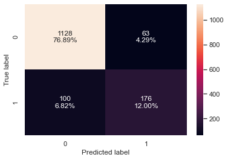

```python
confusion_matrix_sklearn(dtree, X_test, y_test)
```

```python
dtree_model_train_perf = model_performance_classification_sklearn(
    dtree, X_train, y_train
)
print("Training performance \n", dtree_model_train_perf)
```

```
Training performance
    Accuracy  Recall  Precision   F1  ROC-AUC
0       1.0     1.0        1.0  1.0      1.0
```

```python
dtree_model_test_perf = model_performance_classification_sklearn(dtree, X_test, y_test)
print("Testing performance \n", dtree_model_test_perf)
```

```
Testing performance
    Accuracy    Recall  Precision        F1   ROC-AUC
0  0.888889  0.637681   0.736402  0.683495  0.792392
```

**Insights:**

- Decision tree is working well on the training data but is not able to generalize well on the test data concerning the recall.

### Bagging Classifier

```python
bagging = BaggingClassifier(random_state=1)
bagging.fit(X_train, y_train)
```

```
BaggingClassifier(random_state=1)
```

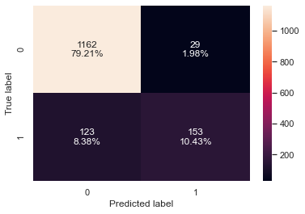

```python
confusion_matrix_sklearn(bagging, X_test, y_test)
```

```python
bagging_model_train_perf = model_performance_classification_sklearn(
    bagging, X_train, y_train
)
print("Training performance \n", bagging_model_train_perf)
```

```
Training performance
    Accuracy    Recall  Precision       F1   ROC-AUC
0  0.993569  0.967391   0.998397  0.98265  0.983516
```

```python
bagging_model_test_perf = model_performance_classification_sklearn(
    bagging, X_test, y_test
)
print("Testing performance \n", bagging_model_test_perf)
```

```
Testing performance
    Accuracy    Recall  Precision        F1   ROC-AUC
0  0.896387  0.554348   0.840659  0.668122  0.764999
```

**Insights:**

- Bagging classifier is overfitting on the training set and is performing poorly on the test set in terms of recall.

### Bagging Classifier with weighted decision tree

```python
bagging_wt = BaggingClassifier(
    base_estimator=DecisionTreeClassifier(
        criterion="gini", class_weight={0: 0.19, 1: 0.81}, random_state=1
    ),
    random_state=1,
)
bagging_wt.fit(X_train, y_train)
```

```
BaggingClassifier(base_estimator=DecisionTreeClassifier(class_weight={0: 0.19,
                                                                      1: 0.81},
                                                        random_state=1),
                  random_state=1)
```

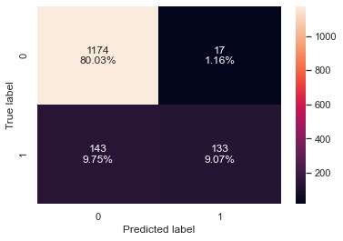

```python
confusion_matrix_sklearn(bagging_wt, X_test, y_test)
```

```python
bagging_wt_model_train_perf = model_performance_classification_sklearn(
    bagging_wt, X_train, y_train
)
print("Training performance \n", bagging_wt_model_train_perf)
```

```
Training performance
    Accuracy    Recall  Precision        F1   ROC-AUC
0  0.992692  0.964286    0.99679  0.980268  0.981783
```

```python
bagging_wt_model_test_perf = model_performance_classification_sklearn(
    bagging_wt, X_test, y_test
)
print("Testing performance \n", bagging_wt_model_test_perf)
```

```
Testing performance
    Accuracy    Recall  Precision        F1   ROC-AUC
0  0.890934  0.481884   0.886667  0.624413  0.733805
```

**Insights:**

- Bagging classifier with a weighted decision tree is giving very good accuracy and precision but is not able to generalize well on test data in terms of recall.

### Random Forest

```python
rf = RandomForestClassifier(random_state=1)
rf.fit(X_train, y_train)
```

```
RandomForestClassifier(random_state=1)
```

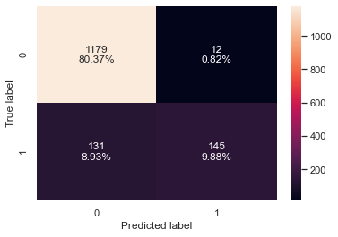

```python
confusion_matrix_sklearn(rf, X_test, y_test)
```

```python
rf_model_train_perf = model_performance_classification_sklearn(rf, X_train, y_train)
print("Training performance \n", rf_model_train_perf)
```

```
Training performance
    Accuracy  Recall  Precision   F1  ROC-AUC
0       1.0     1.0        1.0  1.0      1.0
```

```python
rf_model_test_perf = model_performance_classification_sklearn(rf, X_test, y_test)
print("Testing performance \n", rf_model_test_perf)
```

```
Testing performance
    Accuracy    Recall  Precision        F1   ROC-AUC
0  0.902522  0.525362   0.923567  0.669746  0.757643
```

**Insights:**

- Random Forest has performed well in terms of accuracy and precision, but it is not able to generalize well on the test data in terms of recall.

### Random forest with class weights

```python
rf_wt = RandomForestClassifier(class_weight={0: 0.19, 1: 0.81}, random_state=1)
rf_wt.fit(X_train, y_train)
```

```
RandomForestClassifier(class_weight={0: 0.19, 1: 0.81}, random_state=1)
```

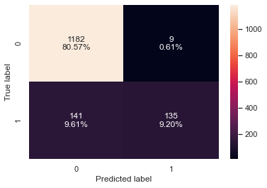

```python
confusion_matrix_sklearn(rf_wt, X_test, y_test)
```

```python
rf_wt_model_train_perf = model_performance_classification_sklearn(
    rf_wt, X_train, y_train
)
print("Training performance \n", rf_wt_model_train_perf)
```

```
Training performance
    Accuracy  Recall  Precision   F1  ROC-AUC
0       1.0     1.0        1.0  1.0      1.0
```

```python
rf_wt_model_test_perf = model_performance_classification_sklearn(rf_wt, X_test, y_test)
print("Testing performance \n", rf_wt_model_test_perf)
```

```
Testing performance
    Accuracy   Recall  Precision        F1   ROC-AUC
0  0.897751  0.48913     0.9375  0.642857  0.740787
```

**Insights:**

- There is not much improvement in metrics of weighted random forest as compared to the unweighted random forest.

### Decision Tree Hyperparameter tuning with GridSearch

```python
# Choose the type of classifier.
dtree_estimator = DecisionTreeClassifier(
    class_weight={0: 0.19, 1: 0.81}, random_state=1
)

# Grid of parameters to choose from
parameters = {
    "max_depth": np.arange(2, 30),
    "min_samples_leaf": [1, 2, 5, 7, 10],
    "max_leaf_nodes": [2, 3, 5, 10, 15],
    "min_impurity_decrease": [0.0001, 0.001, 0.01, 0.1],
}

# Type of scoring used to compare parameter combinations
scorer = metrics.make_scorer(metrics.recall_score)

# Run the grid search
grid_obj = GridSearchCV(dtree_estimator, parameters, scoring=scorer)
grid_obj = grid_obj.fit(X_train, y_train)

# Set the clf to the best combination of parameters
dtree_estimator = grid_obj.best_estimator_

# Fit the best algorithm to the data.
dtree_estimator.fit(X_train, y_train)
```

```
DecisionTreeClassifier(class_weight={0: 0.19, 1: 0.81}, max_depth=7,
                       max_leaf_nodes=15, min_impurity_decrease=0.0001,
                       random_state=1)
```

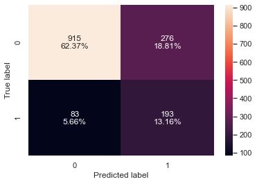

```python
confusion_matrix_sklearn(dtree_estimator, X_test, y_test)
```

```python
dtree_estimator_model_train_perf = model_performance_classification_sklearn(
    dtree_estimator, X_train, y_train
)
print("Training performance \n", dtree_estimator_model_train_perf)
```

```
Training performance
    Accuracy    Recall  Precision        F1   ROC-AUC
0  0.746858  0.698758    0.40107  0.509626  0.728385
```

```python
dtree_estimator_model_test_perf = model_performance_classification_sklearn(
    dtree_estimator, X_test, y_test
)
print("Testing performance \n", dtree_estimator_model_test_perf)
```

```
Testing performance
    Accuracy    Recall  Precision        F1   ROC-AUC
0  0.755283  0.699275   0.411514  0.518121  0.733769
```

**Insights:**

- Recall has improved compared to the Decision Tree Classifier without tuning.
- But accuracy and precision have dropped which is an indication that overall the model is making many mistakes.

### Bagging Hyperparameter tuning with GridSearch

```python
# grid search for bagging classifier
cl1 = DecisionTreeClassifier(class_weight={0: 0.19, 1: 0.81}, random_state=1)
param_grid = {
    "base_estimator": [cl1],
    "n_estimators": [5, 7, 15, 51, 101],
    "max_features": [0.7, 0.8, 0.9, 1],
}

grid = GridSearchCV(
    BaggingClassifier(random_state=1, bootstrap=True),
    param_grid=param_grid,
    scoring="recall",
    cv=5,
)
grid.fit(X_train, y_train)
```

```
GridSearchCV(cv=5, estimator=BaggingClassifier(random_state=1),
             param_grid={'base_estimator': [DecisionTreeClassifier(class_weight={0: 0.19,
                                                                                 1: 0.81},
                                                                   random_state=1)],
                         'max_features': [0.7, 0.8, 0.9, 1],
                         'n_estimators': [5, 7, 15, 51, 101]},
             scoring='recall')
```

```python
## getting the best estimator
bagging_estimator = grid.best_estimator_
bagging_estimator.fit(X_train, y_train)
```

```
BaggingClassifier(base_estimator=DecisionTreeClassifier(class_weight={0: 0.19,
                                                                      1: 0.81},
                                                        random_state=1),
                  max_features=0.9, n_estimators=51, random_state=1)
```

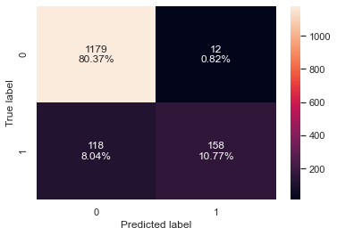

```python
confusion_matrix_sklearn(bagging_estimator, X_test, y_test)
```

```python
bagging_estimator_model_train_perf = model_performance_classification_sklearn(
    bagging_estimator, X_train, y_train
)
print("Training performance \n", bagging_estimator_model_train_perf)
```

```
Training performance
    Accuracy    Recall  Precision        F1   ROC-AUC
0  0.999708  0.998447        1.0  0.999223  0.999224
```

```python
bagging_estimator_model_test_perf = model_performance_classification_sklearn(
    bagging_estimator, X_test, y_test
)
print("Testing performance \n", bagging_estimator_model_test_perf)
```

```
Testing performance
    Accuracy    Recall  Precision       F1   ROC-AUC
0  0.911384  0.572464   0.929412  0.70852  0.781194
```

**Insights:**

- Accuracy and Precision are high compared to the Bagging classifier without tuning.
- Recall score has also improved compared to the classifier without tuning

### Random Forest Hyperparameter tuning with GridSearch

```python
# Choose the type of classifier.
rf_estimator = RandomForestClassifier(random_state=1)

# Grid of parameters to choose from
parameters = {
    "n_estimators": [110, 251, 501],
    "min_samples_leaf": np.arange(1, 6, 1),
    "max_features": [0.7, 0.9, "log2", "auto"],
    "max_samples": [0.7, 0.9, None],
}

# Run the grid search
grid_obj = GridSearchCV(rf_estimator, parameters, scoring="recall", cv=5)
grid_obj = grid_obj.fit(X_train, y_train)

# Set the clf to the best combination of parameters
rf_estimator = grid_obj.best_estimator_

# Fit the best algorithm to the data.
rf_estimator.fit(X_train, y_train)
```

```
RandomForestClassifier(max_features=0.9, n_estimators=501, random_state=1)
```

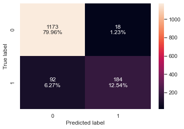

```python
confusion_matrix_sklearn(rf_estimator, X_test, y_test)
```

```python
rf_estimator_model_train_perf = model_performance_classification_sklearn(
    rf_estimator, X_train, y_train
)
print("Training performance \n", rf_estimator_model_train_perf)
```

```
Training performance
    Accuracy  Recall  Precision   F1  ROC-AUC
0       1.0     1.0        1.0  1.0      1.0
```

```python
rf_estimator_model_test_perf = model_performance_classification_sklearn(
    rf_estimator, X_test, y_test
)
print("Testing performance \n", rf_estimator_model_test_perf)
```

```
Testing performance
    Accuracy    Recall  Precision        F1   ROC-AUC
0  0.925017  0.666667   0.910891  0.769874  0.825777
```

**Insights:**

## Boosting

### AdaBoost Classifier

```python
abc = AdaBoostClassifier(random_state=1)
abc.fit(X_train, y_train)
```

```
AdaBoostClassifier(random_state=1)
```

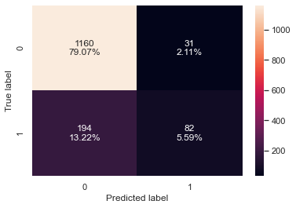

```python
confusion_matrix_sklearn(abc, X_test, y_test)
```

```python
# Using above defined function to get accuracy, recall and precision on train and test set
abc_model_train_perf = model_performance_classification_sklearn(abc, X_train, y_train)
print("Training performance \n", abc_model_train_perf)
```

```
Training performance
    Accuracy    Recall  Precision        F1   ROC-AUC
0   0.84449  0.298137   0.705882  0.419214  0.634664
```

```python
abc_model_test_perf = model_performance_classification_sklearn(abc, X_test, y_test)
print("Testing performance \n", abc_model_test_perf)
```

```
Testing performance
    Accuracy    Recall  Precision        F1   ROC-AUC
0  0.846626  0.297101   0.725664  0.421594  0.635536
```

**Insights:**

- AdaBoost is giving poor performance, in terms of Recall and F1 score
- Low test recall implies that the model is not good at identifying right customers and reducing false negatives

### Gradient Boosting Classifier

```python
gbc = GradientBoostingClassifier(
    init=AdaBoostClassifier(random_state=1), random_state=1
)
gbc.fit(X_train, y_train)
```

```
GradientBoostingClassifier(init=AdaBoostClassifier(random_state=1),
                           random_state=1)
```

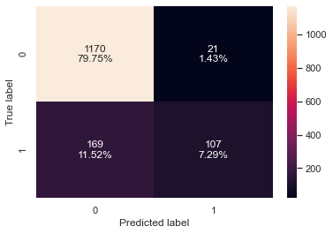

```python
confusion_matrix_sklearn(gbc, X_test, y_test)
```

```python
# Using above defined function to get accuracy, recall and precision on train and test set
gbc_model_train_perf = model_performance_classification_sklearn(gbc, X_train, y_train)
print("Training performance \n", gbc_model_train_perf)
```

```
Training performance
    Accuracy    Recall  Precision        F1   ROC-AUC
0  0.886291  0.453416   0.887538  0.600206  0.720046
```

```python
gbc_model_test_perf = model_performance_classification_sklearn(gbc, X_test, y_test)
print("Testing performance \n", gbc_model_test_perf)
```

```
Testing performance
    Accuracy    Recall  Precision        F1   ROC-AUC
0  0.870484  0.387681   0.835938  0.529703  0.685024
```

**Insights:**

- Gradient boosting is generalizing well but recall and F1 scores are low
- Test recall is better than AdaBoost but way worse than tuned Random Forest

### XGBoost Classifier

```python
xgb = XGBClassifier(random_state=1, eval_metric="logloss")
xgb.fit(X_train, y_train)
```

```
XGBClassifier(base_score=0.5, booster='gbtree', colsample_bylevel=1,
              colsample_bynode=1, colsample_bytree=1, eval_metric='logloss',
              gamma=0, gpu_id=-1, importance_type='gain',
              interaction_constraints='', learning_rate=0.300000012,
              max_delta_step=0, max_depth=6, min_child_weight=1, missing=nan,
              monotone_constraints='()', n_estimators=100, n_jobs=16,
              num_parallel_tree=1, random_state=1, reg_alpha=0, reg_lambda=1,
              scale_pos_weight=1, subsample=1, tree_method='exact',
              validate_parameters=1, verbosity=None)
```

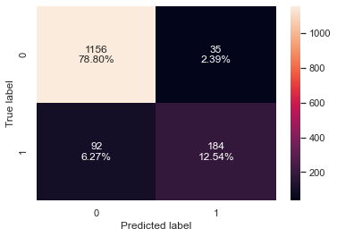

```python
confusion_matrix_sklearn(xgb, X_test, y_test)
```

```python
# Using above defined function to get accuracy, recall and precision on train and test set
xgb_model_train_perf = model_performance_classification_sklearn(xgb, X_train, y_train)
print("Training performance \n", xgb_model_train_perf)
```

```
Training performance
    Accuracy    Recall  Precision        F1   ROC-AUC
0  0.998538  0.992236        1.0  0.996103  0.996118
```

```python
xgb_model_test_perf = model_performance_classification_sklearn(xgb, X_test, y_test)
print("Testing performance \n", xgb_model_test_perf)
```

```
Testing performance
    Accuracy    Recall  Precision        F1  ROC-AUC
0  0.913429  0.666667   0.840183  0.743434  0.81864
```

**Insights:**

- XGBoost with default parameters is giving almost as good results as the tuned Random Forest model
- Recall score matches the tuned Random Forest model and F1 score is very close too

### AdaBoost Hyperparameter Tuning

```python
# Choose the type of classifier.
abc_tuned = AdaBoostClassifier(random_state=1)

# Grid of parameters to choose from
## add from article
parameters = {
    # Let's try different max_depth for base_estimator
    "base_estimator": [
        DecisionTreeClassifier(max_depth=1, random_state=1),
        DecisionTreeClassifier(max_depth=2, random_state=1),
        DecisionTreeClassifier(max_depth=3, random_state=1),
    ],
    "n_estimators": np.arange(10, 110, 10),
    "learning_rate": np.arange(0.1, 2, 0.1),
}

# Type of scoring used to compare parameter combinations
acc_scorer = metrics.make_scorer(metrics.recall_score)

# Run the grid search
grid_obj = GridSearchCV(abc_tuned, parameters, scoring=acc_scorer, cv=5)
grid_obj = grid_obj.fit(X_train, y_train)

# Set the clf to the best combination of parameters
abc_tuned = grid_obj.best_estimator_

# Fit the best algorithm to the data.
abc_tuned.fit(X_train, y_train)
```

```
AdaBoostClassifier(base_estimator=DecisionTreeClassifier(max_depth=3,
                                                         random_state=1),
                   learning_rate=1.5000000000000002, n_estimators=100,
                   random_state=1)
```

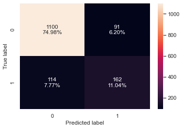

```python
confusion_matrix_sklearn(abc_tuned, X_test, y_test)
```

```python
# Using above defined function to get accuracy, recall and precision on train and test set
abc_tuned_model_train_perf = model_performance_classification_sklearn(
    abc_tuned, X_train, y_train
)
print("Training performance \n", abc_tuned_model_train_perf)
```

```
Training performance
    Accuracy    Recall  Precision        F1   ROC-AUC
0  0.983923  0.944099   0.969697  0.956727  0.968629
```

```python
abc_tuned_model_test_perf = model_performance_classification_sklearn(
    abc_tuned, X_test, y_test
)
print("Testing performance \n", abc_tuned_model_test_perf)
```

```
Testing performance
    Accuracy    Recall  Precision        F1   ROC-AUC
0  0.860259  0.586957   0.640316  0.612476  0.755275
```

**Insights:**

### Gradient Boosting Classifier Tuning

```python
# Choose the type of classifier.
gbc_tuned = GradientBoostingClassifier(
    init=AdaBoostClassifier(random_state=1), random_state=1
)

# Grid of parameters to choose from
parameters = {
    "n_estimators": [100, 150, 200, 250],
    "subsample": [0.8, 0.9, 1],
    "max_features": [0.7, 0.8, 0.9, 1],
}

# Type of scoring used to compare parameter combinations
acc_scorer = metrics.make_scorer(metrics.recall_score)

# Run the grid search
grid_obj = GridSearchCV(gbc_tuned, parameters, scoring=acc_scorer, cv=5)
grid_obj = grid_obj.fit(X_train, y_train)

# Set the clf to the best combination of parameters
gbc_tuned = grid_obj.best_estimator_

# Fit the best algorithm to the data.
gbc_tuned.fit(X_train, y_train)
```

```
GradientBoostingClassifier(init=AdaBoostClassifier(random_state=1),
                           max_features=0.7, n_estimators=250, random_state=1,
                           subsample=1)
```

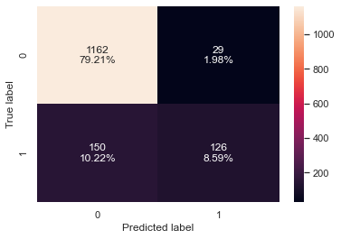

```python
confusion_matrix_sklearn(gbc_tuned, X_test, y_test)
```

```python
# Using above defined function to get accuracy, recall and precision on train and test set
gbc_tuned_model_train_perf = model_performance_classification_sklearn(
    gbc_tuned, X_train, y_train
)
print("Training performance \n", gbc_tuned_model_train_perf)
```

```
Training performance
    Accuracy    Recall  Precision        F1   ROC-AUC
0  0.911722  0.580745   0.921182  0.712381  0.784611
```

```python
gbc_tuned_model_test_perf = model_performance_classification_sklearn(
    gbc_tuned, X_test, y_test
)
print("Testing performance \n", gbc_tuned_model_test_perf)
```

```
Testing performance
    Accuracy    Recall  Precision        F1   ROC-AUC
0  0.877982  0.456522   0.812903  0.584687  0.716086
```

**Insights:**

- The model performace has not increased by much when compared to the untuned model
- It is better at identifying non-buyers than identifying buyers which is the opposite of the result we need

### Stacking

Now, let's build a stacking model with the tuned models - decision tree, random forest, and gradient boosting, then use XGBoost to get the final prediction.

```python
estimators = [
    ("Decision Tree", dtree_estimator),
    ("Random Forest", rf_estimator),
    ("Gradient Boosting", gbc_tuned),
]
final_estimator = XGBClassifier(random_state=1, eval_metric="logloss")
```

```python
stacking_estimator = StackingClassifier(
    estimators=estimators, final_estimator=final_estimator, cv=5
)
stacking_estimator.fit(X_train, y_train)
```

```
StackingClassifier(cv=5,
                   estimators=[('Decision Tree',
                                DecisionTreeClassifier(class_weight={0: 0.19,
                                                                     1: 0.81},
                                                       max_depth=7,
                                                       max_leaf_nodes=15,
                                                       min_impurity_decrease=0.0001,
                                                       random_state=1)),
                               ('Random Forest',
                                RandomForestClassifier(max_features=0.9,
                                                       n_estimators=501,
                                                       random_state=1)),
                               ('Gradient Boosting',
                                GradientBoostingClassifier(init=AdaBoostClassifier(random_st...
                                                 importance_type='gain',
                                                 interaction_constraints=None,
                                                 learning_rate=None,
                                                 max_delta_step=None,
                                                 max_depth=None,
                                                 min_child_weight=None,
                                                 missing=nan,
                                                 monotone_constraints=None,
                                                 n_estimators=100, n_jobs=None,
                                                 num_parallel_tree=None,
                                                 random_state=1, reg_alpha=None,
                                                 reg_lambda=None,
                                                 scale_pos_weight=None,
                                                 subsample=None,
                                                 tree_method=None,
                                                 validate_parameters=None,
                                                 verbosity=None))
```

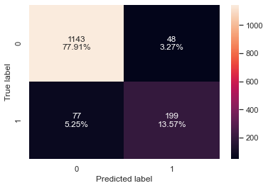

```python
confusion_matrix_sklearn(stacking_estimator, X_test, y_test)
```

```python
# Using above defined function to get accuracy, recall and precision on train and test set
stacking_estimator_model_train_perf = model_performance_classification_sklearn(
    stacking_estimator, X_train, y_train
)
print("Training performance \n", stacking_estimator_model_train_perf)
```

```
Training performance
    Accuracy    Recall  Precision       F1   ROC-AUC
0  0.995031  0.982919    0.99061  0.98675  0.990379
```

```python
stacking_estimator_model_test_perf = model_performance_classification_sklearn(
    stacking_estimator, X_test, y_test
)
print("Testing performance \n", stacking_estimator_model_test_perf)
```

```
Testing performance
    Accuracy    Recall  Precision        F1   ROC-AUC
0  0.914792  0.721014   0.805668  0.760994  0.840356
```

**Insights:**

- Stacking model has produced excellent results in all the metrics
- This model has the highest recall in all the models that we have tested today

## Comparing all the models

```python
# training performance comparison
models = pd.Series(
    [
        "Decision Tree",
        "Bagging Classifier",
        "Weighted Bagging Classifier",
        "Random Forest Classifier",
        "Weighted Random Forest Classifier",
        "Decision Tree Tuned",
        "Bagging Tuned",
        "Random Forest Tuned",
        "Adaboost Classifier",
        "Adaboost Tuned",
        "Gradient Boost Classifier",
        "Gradient Boost Tuned",
        "XGB Classifier",
        "Stacking Classifier",
    ],
)
models_train_comp_df = pd.concat(
    [
        dtree_model_train_perf,
        bagging_model_train_perf,
        bagging_wt_model_train_perf,
        rf_model_train_perf,
        rf_wt_model_train_perf,
        dtree_estimator_model_train_perf,
        bagging_estimator_model_train_perf,
        rf_estimator_model_train_perf,
        abc_model_train_perf,
        abc_tuned_model_train_perf,
        gbc_model_train_perf,
        gbc_tuned_model_train_perf,
        xgb_model_train_perf,
        stacking_estimator_model_train_perf,
    ],
    axis=0,
    ignore_index=True,
)
models_train_comp_df.insert(0, "Models", models)
print("Training performance comparison:")
models_train_comp_df
```

```
Training performance comparison:
```

|  | Models | Accuracy | Recall | Precision | F1 | ROC-AUC |
| --- | --- | --- | --- | --- | --- | --- |
| 0 | Decision Tree | 1.000000 | 1.000000 | 1.000000 | 1.000000 | 1.000000 |
| 1 | Bagging Classifier | 0.993569 | 0.967391 | 0.998397 | 0.982650 | 0.983516 |
| 2 | Weighted Bagging Classifier | 0.992692 | 0.964286 | 0.996790 | 0.980268 | 0.981783 |
| 3 | Random Forest Classifier | 1.000000 | 1.000000 | 1.000000 | 1.000000 | 1.000000 |
| 4 | Weighted Random Forest Classifier | 1.000000 | 1.000000 | 1.000000 | 1.000000 | 1.000000 |
| 5 | Decision Tree Tuned | 0.746858 | 0.698758 | 0.401070 | 0.509626 | 0.728385 |
| 6 | Bagging Tuned | 0.999708 | 0.998447 | 1.000000 | 0.999223 | 0.999224 |
| 7 | Random Forest Tuned | 1.000000 | 1.000000 | 1.000000 | 1.000000 | 1.000000 |
| 8 | Adaboost Classifier | 0.844490 | 0.298137 | 0.705882 | 0.419214 | 0.634664 |
| 9 | Adaboost Tuned | 0.983923 | 0.944099 | 0.969697 | 0.956727 | 0.968629 |
| 10 | Gradient Boost Classifier | 0.886291 | 0.453416 | 0.887538 | 0.600206 | 0.720046 |
| 11 | Gradient Boost Tuned | 0.911722 | 0.580745 | 0.921182 | 0.712381 | 0.784611 |
| 12 | XGB Classifier | 0.998538 | 0.992236 | 1.000000 | 0.996103 | 0.996118 |
| 13 | Stacking Classifier | 0.995031 | 0.982919 | 0.990610 | 0.986750 | 0.990379 |

```python
# testing performance comparison
models = pd.Series(
    [
        "Decision Tree",
        "Bagging Classifier",
        "Weighted Bagging Classifier",
        "Random Forest Classifier",
        "Weighted Random Forest Classifier",
        "Decision Tree Tuned",
        "Bagging Tuned",
        "Random Forest Tuned",
        "Adaboost Classifier",
        "Adaboost Tuned",
        "Gradient Boost Classifier",
        "Gradient Boost Tuned",
        "XGB Classifier",
        "Stacking Classifier",
    ],
)

models_test_comp_df = pd.concat(
    [
        dtree_model_test_perf,
        bagging_model_test_perf,
        bagging_wt_model_test_perf,
        rf_model_test_perf,
        rf_wt_model_test_perf,
        dtree_estimator_model_test_perf,
        bagging_estimator_model_test_perf,
        rf_estimator_model_test_perf,
        abc_model_test_perf,
        abc_tuned_model_test_perf,
        gbc_model_test_perf,
        gbc_tuned_model_test_perf,
        xgb_model_test_perf,
        stacking_estimator_model_test_perf,
    ],
    axis=0,
    ignore_index=True,
)
models_test_comp_df.insert(0, "Models", models)
print("Testing performance comparison:")
models_test_comp_df
```

```
Testing performance comparison:
```

|  | Models | Accuracy | Recall | Precision | F1 | ROC-AUC |
| --- | --- | --- | --- | --- | --- | --- |
| 0 | Decision Tree | 0.888889 | 0.637681 | 0.736402 | 0.683495 | 0.792392 |
| 1 | Bagging Classifier | 0.896387 | 0.554348 | 0.840659 | 0.668122 | 0.764999 |
| 2 | Weighted Bagging Classifier | 0.890934 | 0.481884 | 0.886667 | 0.624413 | 0.733805 |
| 3 | Random Forest Classifier | 0.902522 | 0.525362 | 0.923567 | 0.669746 | 0.757643 |
| 4 | Weighted Random Forest Classifier | 0.897751 | 0.489130 | 0.937500 | 0.642857 | 0.740787 |
| 5 | Decision Tree Tuned | 0.755283 | 0.699275 | 0.411514 | 0.518121 | 0.733769 |
| 6 | Bagging Tuned | 0.911384 | 0.572464 | 0.929412 | 0.708520 | 0.781194 |
| 7 | Random Forest Tuned | 0.925017 | 0.666667 | 0.910891 | 0.769874 | 0.825777 |
| 8 | Adaboost Classifier | 0.846626 | 0.297101 | 0.725664 | 0.421594 | 0.635536 |
| 9 | Adaboost Tuned | 0.860259 | 0.586957 | 0.640316 | 0.612476 | 0.755275 |
| 10 | Gradient Boost Classifier | 0.870484 | 0.387681 | 0.835938 | 0.529703 | 0.685024 |
| 11 | Gradient Boost Tuned | 0.877982 | 0.456522 | 0.812903 | 0.584687 | 0.716086 |
| 12 | XGB Classifier | 0.913429 | 0.666667 | 0.840183 | 0.743434 | 0.818640 |
| 13 | Stacking Classifier | 0.914792 | 0.721014 | 0.805668 | 0.760994 | 0.840356 |

Although Stacking Classifier has the best Recall score, **Tuned Random Forest** has a comparable Recall score. In addition, tuned Random Forest also has excellent Accuracy and Precision and good F1, ROC-AUC scores.

In the spirit of using a less complex model which has a comparable Recall score and very good overall metric scores, **Tuned Random Forest** is the best model to predict which customer will purchase a Travel package

### Feature importance of Random Forest

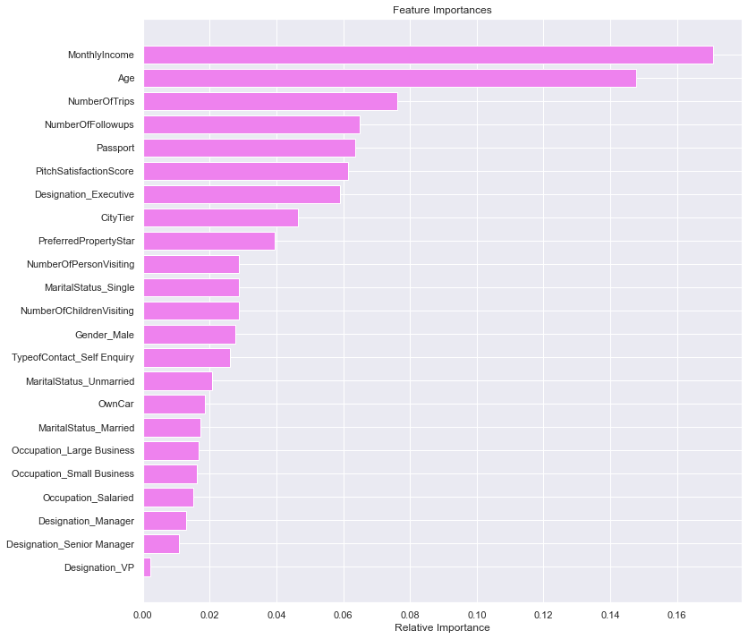

```python
feature_names = X_train.columns
importances = rf_estimator.feature_importances_
indices = np.argsort(importances)

plt.figure(figsize=(12, 12))
plt.title("Feature Importances")
plt.barh(range(len(indices)), importances[indices], color="violet", align="center")
plt.yticks(range(len(indices)), [feature_names[i] for i in indices])
plt.xlabel("Relative Importance")
plt.show()
```

- Monthly Income is the most important feature followed by Age, No of Trips and No of Followups

## Business Insights and Recommendations

- We have been able to build a predictive model:
- - that company can deploy this model to identify customers who are more likely to purchase the wellness travel package.
- - that company can use to find the factors that drive the purchase
- - based on which company can take appropriate actions to build a better marketing campaign and improve the ROI on the marketing budget
- Factors that drive the purchase of - Monthly Income, Age, Number of Trips, No of Followups, Passport, Pitch Satisfaction Score
- Monthly Income: Customers who have not purchased a travel plan tend to have higher median income. We have seen that senior designatios like Sr Manager, VP and SVP tend to have higher incomes. We should target the marketing of wellness package at the high income individuals who have not purchaseda travel package previously.
- Age: We have seen that younger customers tend to buy travel package more compared to older customers. We have also seen that older customers tend to be in a senior designation and hence have more money. The company can provide additional incentives to attract such customers.
- Number of Trips: The more trips a customer takes in a year, higher their designation and inturn high monthly income . We have also seen that only a few VP and SVPs travel but those who travel, take multiple trips in a year. This factor also targets the same demographic of older and wealthier customers. We have also seen a lot of Executives and Managers do 1 or 2 trips a year and have also seen customers from Tier 2 and Tier 3 cities have higher probability of purchasing a travel package. We should target this demographic too.
- No of Followups: The more follow ups that we do with a customer after the pitch, the higher the chance of buying a travel package. This has to be taken up with the sales team to follow up with the customers.
- Passport: Customers who own a passport have higher probability of purchasing a travel package. Targeting executives and managers who own a passport and from tier2 or tier 3 cities (where the penetration is less) will increase the sales.
- Pitch Satisfaction Score: The higher the score, the more probability of customer buying a travel package and this has to be the focus of the sales team to do a good first impression when speaking with the customer. This combined with follups will increase the chances of customer buying the new travel package.